# Sexual dimorphism in Chinstrap penguins

Benedikt Haarscheidt, Jaesub Kim, Ahmed Tijani Akinfalabi

2023-12-18

# Abstract

In this report, we present a comprehensive analysis of sexual dimorphism in Chinstrap penguins (*Pygoscelis antarctica*) through rigorous statistical examination of key morphological characteristics, including body mass, flipper length, bill length, and bill depth. Utilizing population parameters such as means, medians, confidence intervals, and standard deviations, we conducted detailed comparisons. Statistical tests, including Shapiro-Wilk tests, t-tests, effect sizes and chi-square tests, were employed to reinforce our observations.

In order to place our discoveries within a broader avian context, we introduced the Sexual Dimorphism Index (SDI) as a widely acknowledged metric. Our investigation transcends the realm of Chinstrap penguins, encompassing comprehensive comparisons among various penguin species and a diverse array of prey and songbirds. The results consistently reveal a marked degree of sexual dimorphism across all examined penguin species, characterized by males displaying positive dimorphism relative to females. Intriguingly, our findings in prey birds suggest a positive dimorphism in female individuals. When extending this hypothesis to songbirds, it becomes evident that sexual dimorphism is expressed not only in measurable physical attributes but also in distinct behavioral patterns. This study contributes invaluable insights into the pervasive nature of sexual dimorphism within avian populations.

# Introduction

In the intricate web of the natural world, the phenomenon of sexual dimorphism stands out as a captivating manifestation of evolutionary diversity. Just like in the species *homo sapiens*, the animal kingdom showcases a myriad of fascinating adaptations that highlight the distinct physical and behavioral differences between males and females of the same species. Sexual dimorphism, rooted in the forces of natural selection and reproductive strategies, offers a window into the adaptive mechanisms that have shaped countless species over millennia.

From the majestic mane of a male lion to the vibrant plumage of a male peacock, sexual dimorphism is often prominently displayed in the external characteristics of animals. This manifests as differences in size, coloration, behavior, or reproductive anatomy between the sexes of a species. Beyond mere aesthetics, these differences often serve crucial roles in the survival and reproductive success of individuals within a species. A fundamental understanding of the various forms of sexual dimorphism in a variety of species will be an important step toward understanding the evolutionary pressures that have shaped these unique traits and behaviors.

This report is dedicated to the comprehensive examination of sexual dimorphism in the context of penguins, and highlight the ecological and reproductive significance of these differences. By undertaking this investigation, we endeavor to acquire a deeper understanding of the intricate dynamics between males and females within various species, elucidating how evolutionary pressures have contributed to the development of these distinctive relationships.

In Chinstrap penguins (*Pygoscelis antarcticus*), one of the most recognizable and widely studied penguin species, sexual dimorphism manifests notably in aspects such as body mass, flipper length, and bill size. This report aims to explore and quantify the differences between male and female Chinstrap penguins, shedding light on how these disparities play a crucial role in their breeding behavior, survival strategies, and overall ecology.

Chinstrap penguins, known for their distinctive black band under their heads, inhabit several islands and shores in the Southern Pacific and the Antarctic Ocean. These regions’ harsh and competitive environments necessitate various adaptations, potentially influencing the development of sexual dimorphism. Previous studies have indicated that differences in body size and features between males and females could be attributed to factors like mating competition, foraging efficiency, and parental roles in nurturing the young.

Based on the distinctive traits observed in Chinstrap penguins and the evolutionary pressures associated with their challenging environments, we hypothesize that there exists a significant degree of sexual dimorphism in this species. We anticipate that our investigation will reveal measurable differences in body mass, flipper length, and bill size, providing insights into the ecological and reproductive roles played by male and female Chinstrap penguins.

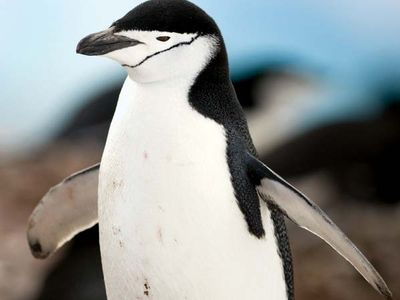

Chinstrap Penguin

# Data

The data employed to substantiate the previously posited hypothesis was sourced from the Palmerpenguins package of the CRAN R library. This package encapsulates an extensive dataset named penguins_raw featuring dimensions such as body mass, size measurements, clutch observations, and blood isotope ratios for adult Adélie, Chinstrap, and Gentoo penguins in the Palmer Archipelago near Palmer Station, Antarctica. Dr. Kristen Gorman and the Palmer Station Long Term Ecological Research (LTER) Program curated and generously shared this dataset, showcasing the collaborative nature of scientific endeavors. Spanning 344 penguins across three distinct species (Adélie, Chinstrap, and Gentoo ), the dataset originates from three islands within the Palmer Archipelago, providing a rich tapestry of geographical diversity. Notably, the dataset includes morphological measurements, with culmen (bill) length and depth thoughtfully renamed as bill_length_mm and bill_depth_mm for clarity, contributing to a nuanced comprehension of penguin ecology. Complementing the morphological data are clutch observations shedding light on the reproductive behavior of the penguins and blood isotope ratios offering insights into their dietary habits and foraging strategies. Furthermore the dataset extends to other sample information such as individual ID of the observed penguin, the sample number, the study name and some comments. Since were interested in performing a descriptive analysis and use the information to abstract and generalize, we simply ignore those datapoints and focus on the described relevant ones.

In the pursuit of substantiating the stated hypothesis, our focus is on comparing key characteristics such as bill/culmen length and depth, body mass and flipper size between male and female penguins. The objective is to discern potential sexual dimorphism and its implications in the context of the penguin species under study. Moreover, we intend to extend our analysis by comparing the obtained results with a datasets concerning other avian species. This comparative approach aims to abstract the underlying hypothesis and draw inferences that transcend the confines of the penguin dataset, contributing to a broader understanding of sexual dimorphism and ecological dynamics across diverse species. In our exploration of the palmerpenguins dataset, we focused on pertinent dimensions to substantiate our hypothesis, selectively disregarding columns not integral to our investigation. Below one can see the head of the penguins_raw dataframe.

| studyName | Sample Number | Species | Region | Island | Stage | Individual ID | Clutch Completion | Date Egg | Culmen Length (mm) | Culmen Depth (mm) | Flipper Length (mm) | Body Mass (g) | Sex | Delta 15 N (o/oo) | Delta 13 C (o/oo) | Comments |
| --- | --- | --- | --- | --- | --- | --- | --- | --- | --- | --- | --- | --- | --- | --- | --- | --- |
| PAL0708 | 1 | Adelie Penguin (Pygoscelis adeliae) | Anvers | Torgersen | Adult, 1 Egg Stage | N1A1 | Yes | 2007-11-11 | 39.1 | 18.7 | 181 | 3750 | MALE | NA | NA | Not enough blood for isotopes. |
| PAL0708 | 2 | Adelie Penguin (Pygoscelis adeliae) | Anvers | Torgersen | Adult, 1 Egg Stage | N1A2 | Yes | 2007-11-11 | 39.5 | 17.4 | 186 | 3800 | FEMALE | 8.94956 | -24.69454 | NA |
| PAL0708 | 3 | Adelie Penguin (Pygoscelis adeliae) | Anvers | Torgersen | Adult, 1 Egg Stage | N2A1 | Yes | 2007-11-16 | 40.3 | 18.0 | 195 | 3250 | FEMALE | 8.36821 | -25.33302 | NA |
| PAL0708 | 4 | Adelie Penguin (Pygoscelis adeliae) | Anvers | Torgersen | Adult, 1 Egg Stage | N2A2 | Yes | 2007-11-16 | NA | NA | NA | NA | NA | NA | NA | Adult not sampled. |
| PAL0708 | 5 | Adelie Penguin (Pygoscelis adeliae) | Anvers | Torgersen | Adult, 1 Egg Stage | N3A1 | Yes | 2007-11-16 | 36.7 | 19.3 | 193 | 3450 | FEMALE | 8.76651 | -25.32426 | NA |
| PAL0708 | 6 | Adelie Penguin (Pygoscelis adeliae) | Anvers | Torgersen | Adult, 1 Egg Stage | N3A2 | Yes | 2007-11-16 | 39.3 | 20.6 | 190 | 3650 | MALE | 8.66496 | -25.29805 | NA |

# Statistical analysis

## Data preparation

Statistical analysis were performed using R (version 4.3.1). Our primary objective is to emphasize our hypothesis - highlighting the significant sexual dimorphism with the Chinstrap penguins within our datasets. We compared morphological measurements (Body mass, Bill length, Bill depth, and Flipper length) between male and female penguins using various statistical approaches and tests to further buttress our hypothesis. Firstly, since our dataset was from the Palmerpenguins library containing 3 (three) different penguin species (Adelie, Chinstrap, and Gentoo), it was imperative to isolate the datasets for only the Chinstrap penguins since that is our focus for this report and to then further analyze the data.

See below the distribution of sexes within the Palmerpenguins dataset:

|  | Adelie Penguin (Pygoscelis adeliae) | Chinstrap penguin (Pygoscelis antarctica) | Gentoo penguin (Pygoscelis papua) |
| --- | --- | --- | --- |
| FEMALE | 73 | 34 | 58 |
| MALE | 73 | 34 | 61 |

Given our specific focus on the Chinstrap species within the Palmer penguins package, it is imperative to create subsets corresponding to each penguin species within the general dataset. While we currently require this subset specifically for the Chinstrap species, anticipating potential use for the other subsets later in this report prompts us to perform this subsetting procedure for all penguin species at this stage. By doing so, we ensure that the necessary datasets are readily available for subsequent analyses and facilitate a smoother progression in the later stages of our report.

## Numeric parameters

In the following section, a series of statistical analyses were undertaken to investigate sexual dimorphism in chinstrap penguins. These analyses encompassed the computation of various statistical parameters for bill length and depth, body mass, and flipper length. Parameters such as arithmetic means, medians, and comprehensive summaries were derived, and these will be subsequently utilized in additional statistical analyses or tests. These parameters, will be presented in the results section, contributing to our understanding of sexual dimorphism in chinstrap penguins.

## Statistical tests

### Shapiro-wilke test

To assess the normality of our datasets, we employed the Shapiro-Wilk test, a statistical method used to evaluate whether a given variable follows a normal distribution. This test is particularly sensitive to deviations from normality in small to moderately sized samples.

The Shapiro-Wilk test statistic ($W$) is given by:

$$W = \frac{\left(\sum_{i=1}^{n} a_i
x_{(i)}\right)^2}{\sum_{i=1}^{n} (x_i - \bar{x})^2}$$

where $n$ is the sample size, $x_{(i)}$ is the $i$-th ordered observation, $\bar{x}$ is the sample mean, and $a_i$ are constants dependent on the sample size and the covariance matrix of the ordered sample values.

For each relevant variable, we conducted a Shapiro-Wilk test, where the null hypothesis (H0) posits that the data is normally distributed. Conversely, the alternative hypothesis (H1) suggests that the data significantly deviates from a normal distribution.

In the context of our analysis, meeting the assumption of normality is crucial, especially when considering subsequent two-sample t-tests. Because we are focusing on sexual dimorphism in chinstrap penguins, this test and subsequent two-sample t-tests were applied only to the relevant variables in chinstrap.

To meet the assumption of normal distribution, we identified and removed an outlier from bill length of female chinstrap penguins dataset. This step was taken to enhance the normality of the data and ensure the validity of subsequent statistical analyses.

### T-test

Having rigorously assessed the normality of our dataset variables through Shapiro-Wilk tests, our analytical focus now shifts to conducting two-sample t-tests. This statistical method enables us to explore potential differences in specific physical characteristics between distinct groups, such as male and female penguins within each species.

The two-sample t-test statistic ($t$) is given by:

$$t = \frac{\bar{x}_1 -
\bar{x}_2}{\sqrt{s_p \left(\frac{1}{n_1} + \frac{1}{n_2}\right)}}$$

where $\bar{x}$ is the sample mean, $\mu$ is the population mean, $s$ is the sample standard deviation, and $n$ is the sample size.

Hypotheses: To frame our analysis, we establish clear hypotheses. The null hypothesis posits no significant difference between male and female penguins, while the alternative hypothesis anticipates a significant distinction.

Significance Level: Our statistical inferences will be based on a predetermined alpha level (0.05), and p-values resulting from the t-tests will guide our determination of statistical significance.

Application: We apply these t-tests specifically to explore potential differences in physical characteristics between male and female Chinstrap penguins. Considering the normality status of our variables is crucial, as the validity of t-tests relies on the assumption of normal distribution. Insights gained from the Shapiro-Wilk tests inform the selection of appropriate statistical analyses.

By employing these robust statistical techniques, we aim to uncover nuanced variations in physical attributes, contributing to a comprehensive understanding of sexual dimorphism within penguin species.

### Quantile splitting

```
## Margins computed over dimensions
## in the following order:
## 1:
## 2: cWeight
```

```
## Margins computed over dimensions
## in the following order:
## 1:
## 2: cblen
```

```
## Margins computed over dimensions
## in the following order:
## 1:
## 2: cbdep
```

```
## Margins computed over dimensions
## in the following order:
## 1:
## 2: cflen
```

### Effectsize

#### Cohen’s D

Effect size, exemplified by metrics like Cohen’s d in our two-sample t-tests, is crucial in statistical analyses for its role in providing a standardized measure of observed differences. Going beyond statistical significance, Cohen’s d is calculated by dividing the difference between group means by the pooled standard deviation, expressing the extent of group differences in standard deviations.

$$d = \frac{\bar{x}_1 - \bar{x}_2}{s_p}$$

where $\bar{x}_1, \bar{x}_2$ are the means of two independent samples and $s_p$ is the pooled standard deviation.

This standardized unit of measurement is independent of variable scales, enabling comparisons across studies. Guidelines for interpreting Cohen’s d suggest that a small effect size is around 0.2, a medium size is approximately 0.5, and a large size is about 0.8 or higher. The sign of Cohen’s d indicates the effect’s direction: positive values imply a higher mean in the first group, and negative values suggest the opposite. In our case, applying Cohen’s d to differences in bill length, bill depth, flipper length, and body mass among male and female penguins provides nuanced insights, moving beyond statistical significance to assess the practical impact of these variations in physical characteristics.

## Chi-Square Test of Independence Formula

In order to explore the potential relationship between sex and various physical characteristics of Chinstrap penguins, namely Body Mass, Flipper Length, Bill Length, and Bill Depth, we employed the chi-square test.

The chi-square test of independence is calculated using the formula:

$$\chi^2 = \sum \frac{(O_{ij} -
E_{ij})^2}{E_{ij}}$$

where $\chi^2$ is the test statistic, $O_{ij}$ is the observed frequency in cell $ij$, and $E_{ij}$ is the expected frequency in cell $ij$.

Hypothesis: Our investigation aims to determine if there is a significant association between the sex of Chinstrap penguins and their respective Body Mass, Flipper Length, Bill Length, and Bill Depth.

Application: We apply the chi-square test to assess the independence of the observed frequencies within the specified categories. By comparing observed and expected frequencies, we aim to unveil any significant patterns or deviations that may indicate a relationship between sex and the selected physical characteristics.

Interpretation: The resulting chi-square statistic will be evaluated against critical values to determine statistical significance. Any observed differences between the expected and observed frequencies will guide our understanding of the potential dependence between sex and the physical attributes of Chinstrap penguins.

This statistical approach enhances our analysis by providing insights into the interplay between sex and various characteristics, contributing to a comprehensive exploration of sexual dimorphism within the Chinstrap penguin population.

## Interspecies comparison

In our methodology, we strategically expand our comparisons to encompass a broader range of species, seeking to validate our hypotheses and derive meaningful insights. To achieve this, we include the Adelie penguin species, utilizing available data from the Palmer penguins package. This addition enhances the diversity of our dataset and contributes to a more comprehensive understanding of sexual dimorphism. Our methodology involves a detailed comparison based on values derived from existing datasets, and the results of these comparisons will be presented in the subsequent Results section. Moreover, to enrich the scope of our study and facilitate broader conclusions across different avian species, we plan to incorporate datasets related to songbirds and prey birds. These datasets, provided by Valcu, Valcu, and Kempenaers (2023), extend our comparative analysis to include a wider biological context. This meticulous approach aligns with the methodological rigor necessary for our investigation into sexual dimorphism in penguins.

### SDI - Sexual Dimorphism Index

The SDI for each measurement was computed using the formula:

$$SDI = \left( \frac{{\text{larger
sex}}}{{\text{smaller sex}}} - 1 \right)$$

The index was arbitrarily set to be positive when males were larger and negative when females were larger, following the convention established by Lovich and Gibbons (1992).

Subsequently, the Sexual Size Dimorphism (SSD) was estimated by calculating the SDI for all male-female pairs within each penguin species. This step allowed for the comprehensive assessment of sexual dimorphism across the entire dataset.

The SDI methodology provides a robust framework for quantifying and comparing sexual dimorphism in penguin species and offers insights into the morphological variations between male and female individuals. The results contribute to our understanding of the ecological and evolutionary dynamics shaping the observed sexual dimorphism in these avian species. Furthermore we are going to compare the SDI of the penguin species in the dataset to other preybird and songbird species in the discussion section.

# Results

## Comparison of the descriptive parameters

### Mean

The presented table outlines the arithmetic means of key physical characteristics for male and female penguins. These characteristics, encompassing body mass, flipper length, bill length, and bill depth, offer a comprehensive overview of the average measurements within each gender. Notably, male penguins exhibit a higher mean body mass, flipper length, bill length, and bill depth compared to their female counterparts. These distinctions may reflect inherent biological differences between male and female individuals within the studied penguin population.

```
## Table: Arithmetic Means of Physical Characteristics (Male vs Female)
```

|  | mean body mass g | mean flipper length mm | mean bill length mm | mean bill depth mm |
| --- | --- | --- | --- | --- |
| MALE | 3938.971 | 199.9118 | 51.09412 | 19.25294 |
| FEMALE | 3527.206 | 191.7353 | 46.57353 | 17.58824 |

### Standard deviation

```
## Table: SD (standard deviation from mean) of Physical Characteristics (Male vs Female)
```

|  | SD body mass g | SD flipper length mm | SD bill length mm | SD bill depth mm |
| --- | --- | --- | --- | --- |
| MALE | 362.1376 | 5.976559 | 1.564558 | 0.7612730 |
| FEMALE | 285.3339 | 5.754096 | 3.108669 | 0.7811277 |

### Exploring Penguin Physiques: Visualizations and Descriptive Metrics

To gain a more nuanced understanding of the distribution of physical characteristics among male and female penguins, histograms are employed to visually represent the frequency and pattern of measurements within each gender. Histograms serve as insightful tools, offering a graphical depiction of how individual measurements are distributed across the population. By examining these visual representations alongside the previously presented mean and standard deviation tables, we can discern not only the central tendencies but also the spread and variation within the male and female penguin populations. The histograms provide a comprehensive view of the underlying distribution patterns, shedding light on the diversity of physical traits exhibited by these fascinating avian species.

#### Bodymass

Displayed below is a histogram portraying the distribution of body mass among male Chinstrap penguins. The height of each bar corresponds to the number of penguins sharing a similar weight, offering a visual representation of the population’s diversity. Notably, the presence of a density line hints at a potential normal distribution within the sample, a hypothesis to be further validated. Additionally, both the mean and median values for males and females are graphically presented. The female median is depicted with a blue solid line, while the female mean is represented by a black solid line. Notably, both female metrics are situated to the left of their male counterparts, providing an initial observation of sexual dimorphism in body weight. This histogram serves to reinforce the trends highlighted in the previously presented table.

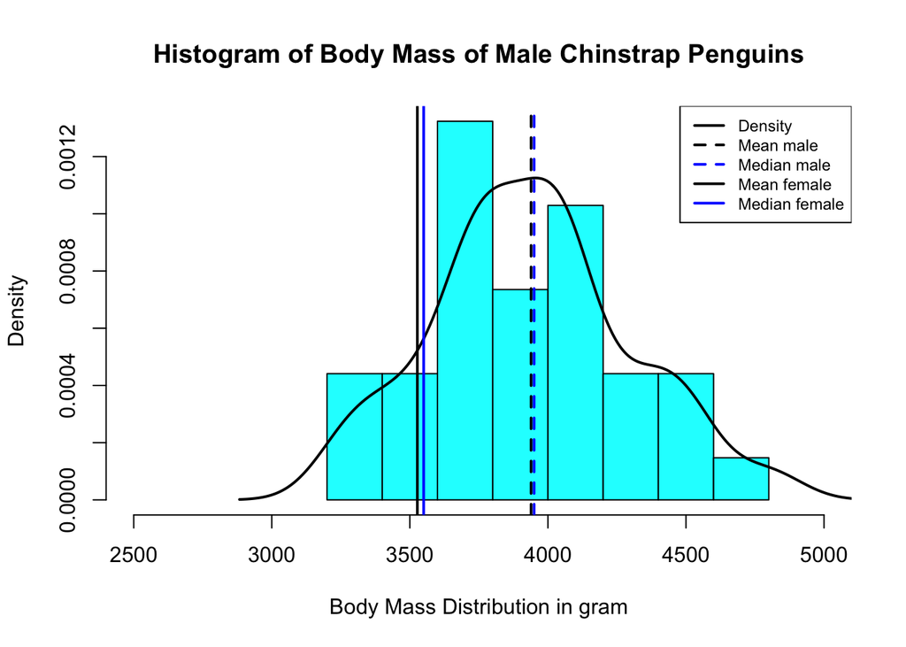

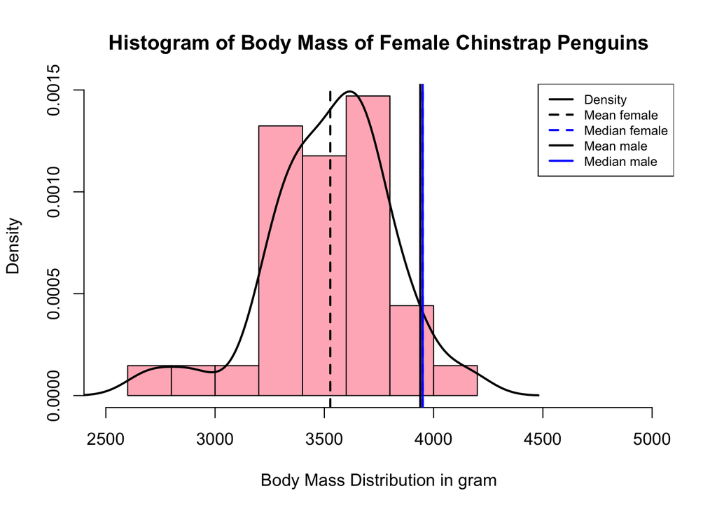

#### Bill/Culmen

##### Length

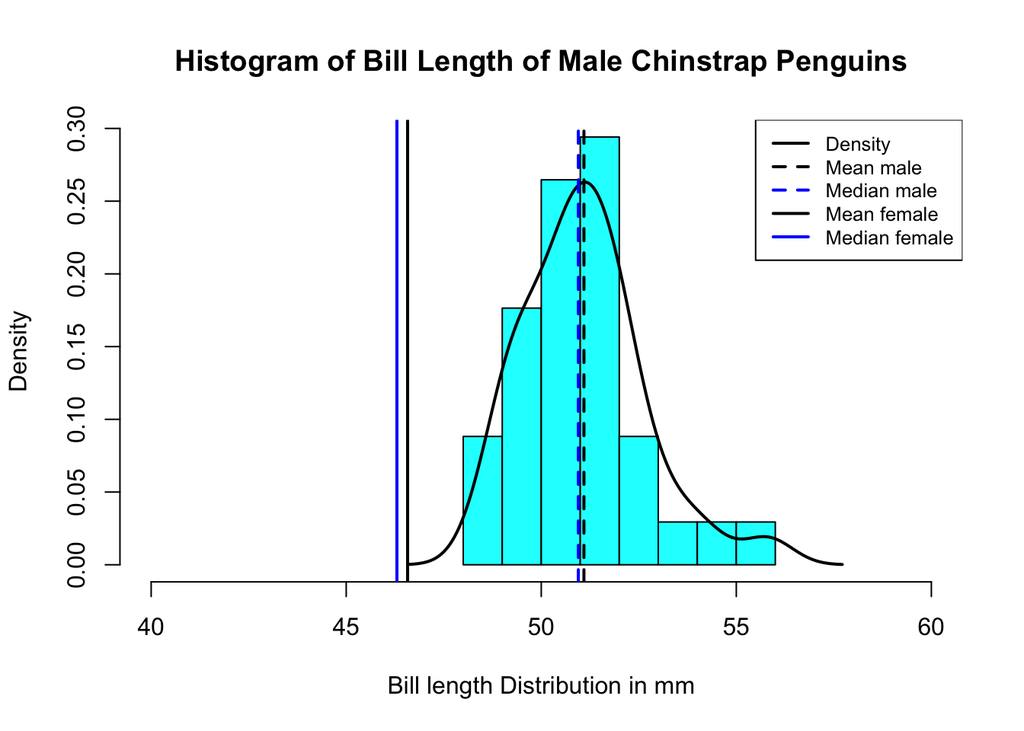

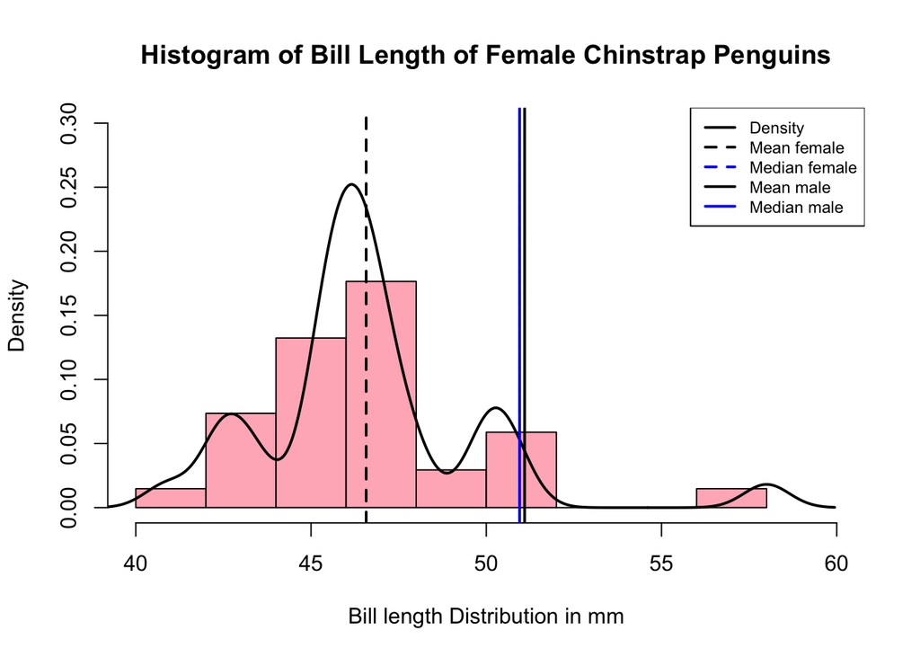

##### Depth

The bill depth distribution for both male and female Chinstrap penguins is succinctly depicted in the accompanying histograms. Similar to the trends observed in body mass and bill length distributions, the histograms portray the frequency of penguins with varying bill depths. The density lines hint at a potential normal distribution, while the mean and median values for each gender are visually presented. Notably, the distribution appears to exhibit comparable trends between males and females. A quick glance at the histograms provides an immediate understanding of the variations in bill depth within the Chinstrap penguin population.

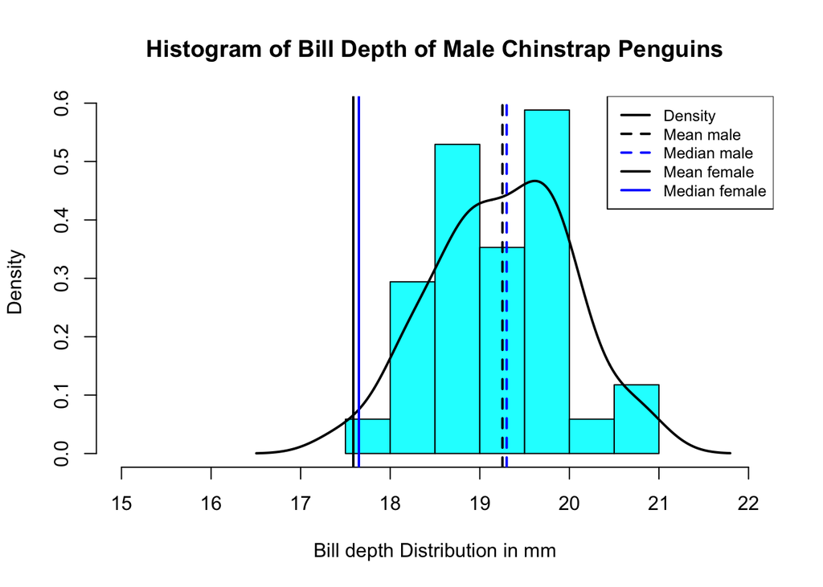

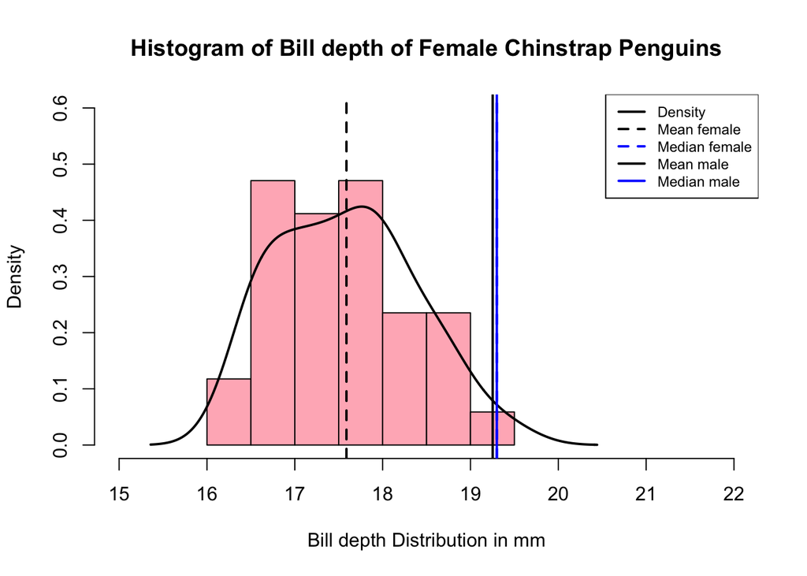

#### Flipper length

The flipper length distributions for male and female Chinstrap penguins are succinctly captured in the accompanying histograms. Mirroring the patterns observed in previous morphological traits, these histograms visually represent the frequency of penguins with various flipper lengths. The density lines offer insights into the potential normal distribution within each gender. The mean and median values for both male and female penguins are visually indicated, revealing trends that align with the broader morphological patterns observed in this captivating avian population. A quick overview of these histograms provides an immediate grasp of the flipper length variations within the Chinstrap penguin community.

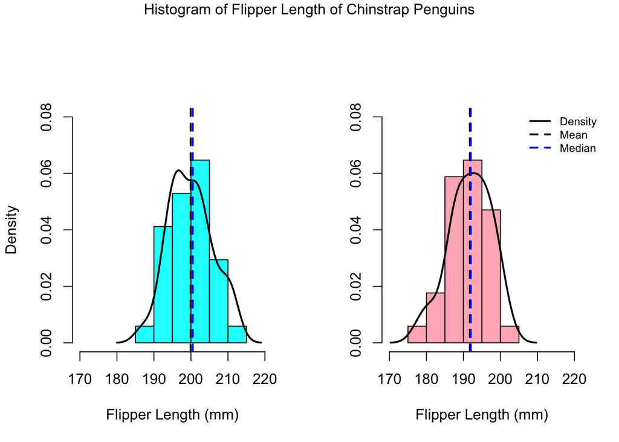

## Utilizing Statistical Tests for In-Depth Exploration

### Shapiro-Wilke test

For each pertinent variable, we executed a Shapiro-Wilk test, wherein the null hypothesis (H0) posits that the data follows a normal distribution, while the alternative hypothesis (H1) suggests a significant departure from normality.

Ensuring the normality assumption is particularly critical in our analysis, especially given the upcoming application of two-sample t-tests. This rigorous evaluation was exclusively applied to relevant variables concerning sexual dimorphism in Chinstrap penguins, aligning with the specific focus of our investigation.

The outcomes of the Shapiro-Wilk test are presented below. P-values exceeding 0.05 affirm the acceptance of the null hypothesis.

| bill_length | bill_depth | flipper_length | body_mass |
| --- | --- | --- | --- |
| 0.1768431 | 0.8625349 | 0.6200637 | 0.8910238 |
| 0.1210097 | 0.2295947 | 0.5074064 | 0.3055292 |

### T Test

Following the comprehensive assessment of normality using Shapiro-Wilk tests, our attention shifts to the outcomes of two-sample t-tests, aimed at unraveling potential differences in specific physical characteristics between different penguin groups, specifically between males and females within each species.

Consideration of Normality: Before delving into the t-test results, it is crucial to acknowledge the normality status of our variables. The validity of t-tests relies on the assumption of normal distribution, and the insights gained from the Shapiro-Wilk tests informed our selection of appropriate statistical analyses.

Summary of Findings: The results of the two-sample t-tests are presented below, highlighting the mean values for female and male penguins within each species, along with the associated p-values. The p-value is a critical metric that indicates the probability of obtaining observed differences if there were no actual differences in the population. A smaller p-value suggests stronger evidence against the null hypothesis of no difference.

| categories | female | male | p-value | significant difference |
| --- | --- | --- | --- | --- |
| Culmen length (mm) | 46.23 | 51.09 | 1e-13 | yes |
| Culmen depth (mm) | 17.59 | 19.25 | 7e-13 | yes |
| flipper length (mm) | 191.7 | 199.9 | 3e-07 | yes |
| body mass (g) | 3527 | 3939 | 3e-07 | yes |

### Quantile splitting

In the analysis of the penguin dataset, we employed segmentation based on quantiles for key morphological characteristics, specifically body weight, bill length, bill depth, and flipper length. This segmentation strategy aimed to categorize individuals into distinct groups, allowing for a more detailed examination of the distribution of features within the population.

The tables below illustrate the distribution of penguins across different quantiles for each morphological trait, categorized by gender. Subsequently, this segmentation facilitated the application of further statistical tests, such as the Chi-Square test and the Cohen’s d test, to explore potential associations and differences between groups.

Table for the quantiles of the bodymass:

|  | light | medium | heavy | sum |
| --- | --- | --- | --- | --- |
| FEMALE | 18 | 12 | 4 | 34 |
| MALE | 5 | 10 | 19 | 34 |
| sum | 23 | 22 | 23 | 68 |

Observation: The table reveals clear sexual dimorphism in body weight, with male penguins tending to be heavier on average compared to females.

Table for the quantiles of the bill length:

|  | short | medium | long | sum |
| --- | --- | --- | --- | --- |
| FEMALE | 25 | 8 | 1 | 34 |
| MALE | 1 | 14 | 19 | 34 |
| sum | 26 | 22 | 20 | 68 |

Observation: Sexual dimorphism is evident in bill length, with males generally exhibiting longer bills compared to females, as indicated by the higher counts in the “long” category for males.

Table for the quantiles of the bill depth:

[output not shown]

Table for the quantiles of the flipper length:

|  | short | medium | long | sum |
| --- | --- | --- | --- | --- |
| FEMALE | 20 | 10 | 4 | 34 |
| MALE | 5 | 11 | 18 | 34 |
| sum | 25 | 21 | 22 | 68 |

Observation: Sexual dimorphism is observable in flipper length, with males generally having longer flippers than females, as indicated by the higher counts in the “long” category for males.

These segmented tables provide a foundation for the subsequent application of statistical tests, allowing for a more in-depth exploration of the relationships and differences in penguin morphological traits across different quantiles. The Chi-Square test will help assess the independence of categorical variables, while the Cohen’s d test will quantify the effect size of observed differences.

### Effect size

In our pursuit of a comprehensive understanding of observed differences, we turn our attention to the concept of effect size, exemplified by metrics such as Cohen’s d in our two-sample t-tests. Effect size is a pivotal component in statistical analyses, offering a standardized measure that transcends the boundaries of statistical significance. In the realm of Cohen’s d, this metric is calculated by dividing the difference between group means by the pooled standard deviation, expressing the extent of group differences in terms of standard deviations. Importantly, this standardized unit of measurement is independent of variable scales, facilitating meaningful comparisons across studies.

Interpreting Cohen’s d: Guidelines for interpreting Cohen’s d provide a qualitative assessment of effect size. A small effect size hovers around 0.2, a medium size is approximately 0.5, and a large size is considered 0.8 or higher. The sign of Cohen’s d conveys the direction of the effect: positive values imply a higher mean in the first group, while negative values suggest the opposite.

| Variable | Cohen_d | Effect_Size |
| --- | --- | --- |
| Body Mass (g) | -1.263061 | Large |
| Culmen Length (mm) | -1.836995 | Large |
| Culmen Depth (mm) | -2.158412 | Large |
| Flipper Length (mm) | -1.393784 | Large |

Interpretation: The resulting Cohen’s d values, computed using the cohen.d function from the effsize library, offer profound insights into the standardized differences between male and female Chinstrap penguins for each physical characteristic. In our context, the consistently large effect sizes across Body Mass, Culmen Length, Culmen Depth, and Flipper Length suggest substantial and practically significant distinctions between male and female penguins within each species.

Significance Beyond Statistical Tests: This move beyond statistical significance enables us to assess the real-world impact of these variations in physical characteristics. By considering effect sizes, we gain a deeper understanding of the practical significance of observed disparities, complementing our inferential statistics and enriching the interpretation of the nuanced differences among the studied attributes.

### Chi-Square test

In our meticulous analysis of chinstrap penguin data, our focus was to discern the intricate association between sex and body size, specifically categorized into three groups: small, medium, and large. The parameters of interest encompassed bill length, bill depth, flipper length, and body mass. To ensure a balanced representation, we leveraged quantiles for the categorization process.

#### Bodymass

```
## [1] 0.0001740572
```

#### Bill length

```
## [1] 2.071268e-09
```

#### Bill depth

[output not shown]

#### Flipper length

```
## [1] 0.0001261101
```

The chi-square independence test results reveal compelling evidence of a statistically significant association between sex and the categorized size groups for all measured attributes. Notably, the p-values across all parameters are exceptionally low (all less than 0.001), indicating a high level of statistical significance.

Body Mass:  
The observed association between sex and body mass categories is highly significant, suggesting that the distribution of penguins across small, medium, and large size groups significantly differs between males and females.

Bill Length:  
The chi-square test underscores a highly significant relationship between sex and bill length categories. This finding implies a distinct distribution pattern of penguins based on bill length among male and female populations.

Bill Depth:  
Similarly, the significant association between sex and bill depth categories implies a meaningful divergence in the distribution of penguins with varying bill depths between male and female groups. Flipper Length:

The chi-square test establishes a highly significant connection between sex and flipper length categories. This suggests a notable disparity in the distribution of penguins across small, medium, and large flipper length categories based on sex.

### SDI - Sexual Dimorphism Index

Subsequently, the Sexual Size Dimorphism (SSD) was estimated by calculating the SDI for all male-female pairs within each penguin species. This step allowed for the comprehensive assessment of sexual dimorphism across the entire dataset.

The data for different avian species were sourced from the database provided by Valcu, Valcu, and Kempenaers (2023). This dataset encompasses information on body mass, wing length, and Sexual Dimorphism Index (SDI) categorized by male and female specimens for various avian species. Given that the database includes statistical values for wing length and body mass, we can compare these metrics with the corresponding flipper length and body mass of the penguins in our dataset. This enables a meaningful assessment of the morphological sexual dimorphism of penguins in relation to the broader avian species data provided. Additionally we note, that form the fourth row of the table until the species Gyps fulvus, the listed species are all preybirds and starting from Malurus amabilis until the last row of the table the avian species are all songbirds.

[output not shown]

We further categorized penguins, prey birds, and songbirds in the above table, calculating the mean SDI for body mass and wing/flipper length within each category. Additionally, an overall SDI was computed. Here it is shown what average SDI each bird classification has.

|  | Mean BM SDI | Mean WL/FL SDI | Mean SDI |
| --- | --- | --- | --- |
| Penguin | 0.163 | 0.036 | 0.100 |
| Prey bird | -0.119 | -0.026 | -0.072 |
| Song bird | 0.005 | 0.015 | 0.010 |

Notably, the mean Sexual Dimorphism Index (SDI) for songbirds appears considerably lower when compared to other avian categories. This underscores the fact that the manifestation of sexual dimorphism extends beyond physical attributes alone.

# Discussion

## Comparison of sexual dimorphism within gentoo penguin genera

The role of beak size in the sexual dimorphism of penguins, whether it contributes to enhanced hunting abilities or serves as a means for intra-species male competition, remains ambiguous. Additional research is imperative to gain a deeper understanding of this aspect in the sexual differentiation of penguins.(Szara et al. (2023),Lee et al. (2015))

## Inverse sexual dimorphism in prey birds

In contrast to the sexual dimorphism observed in the three penguin species, as well as in most songbirds compared, it is noteworthy that the majority of prey bird species used in the comparison exhibit female-biased sexual dimorphism, as depicted in the table. Various intriguing hypotheses have been proposed to explain this phenomenon. Some literature suggests that females, primarily responsible for incubating eggs and defending nests, exhibit female-biased sexual dimorphism. However, this hypothesis lacks generalizability, as it fails to explain cases observed in other bird species. Additionally, the hypothesis that prey birds introduce sexual dimorphism to broaden their prey spectrum has been postulated. Dekker (2009) propose that smaller and faster males primarily hunt smaller prey, while larger females, due to their greater size, focus on larger prey, explaining reverse-size sexual dimorphism.

Another perspective argues that the smaller size of males contributes to their success in hunting situations that demand complex maneuvers in mid-air. This is particularly relevant in species where the strength of sexual dimorphism is more pronounced. For instance, a study on owls suggests that larger, more agile prey is hunted by females with strong sexual dimorphism, implying that natural selection pressures have driven an increase in sexual dimorphism in such species (Krüger (2005)).

## Slight sexual size dimorphism in song birds

The sexual dimorphism observed in Songbirds diverges from the conspicuous sexual size differences found in other avian species, such as Preybirds and Penguins. As can be seen in the table above, the songbirds have a relatively small SDI. In songbirds, as in other avian species, sexual and natural selection clearly placed different evolutionary pressures on each sex, but songbirds appear to have assimilated evolutionary pressures in different directions. (Shultz and Burns (2017)) This can be explained by the differences in sexual roles and courtship methods of songbirds and other bird species. Instead of relying on overt physical characteristics, Songbirds have evolved a unique courtship strategy centered around song selection. This distinctive approach to mate attraction involves complex internal differences rather than external size dimorphism.

Notably, the research by Nottebohm and Arnold (1976) underscores the brain development in male Songbirds, with larger and more developed vocal control regions compared to females. This correlates with the observation that females, with less developed or indistinguishable vocal control areas, generally do not engage in singing behavior. For these reasons , investigations into sexual dimorphism in Songbirds predominantly focused on the intricacies of male vocalization behaviors and the development of male brains and central nervous systems.

Research by Brenowitz and Arnold (1992) and Arnold et al. (1986) further supports the notion that sexual dimorphism in the neural song system is correlated with vocalization abilities. They suggest that hormonal differences between males and females trigger these disparities, emphasizing the role of hormonal control in shaping the sexual dimorphism observed in Songbirds.

As such, the differences between Songbird’s SDI and Penguin’s SDI appear to be due to different courtship strategies, and while Songbirds rely on intricate courtship behaviors and internal neural differences, Penguins demonstrate a more straightforward approach through traditional external size dimorphism.

# Literature

Arnold, Arthur P, Sarah W Bottjer, Eliot A Brenowitz, Ernest J Nordeen, and Kathy W Nordeen. 1986. “Sexual Dimorphisms in the Neural Vocal Control System in Song Birds: Ontogeny and Phylogeny.” *Brain, Behavior and Evolution* 28 (1-3): 22–31.

Brenowitz, Eliot A, and Arthur P Arnold. 1992. “Hormone Accumulation in Song Regions of the Canary Brain.” *Journal of Neurobiology* 23 (7): 871–80.

Dekker, Dick. 2009. *Hunting Tactics of Peregrines and Other Falcons*. Wageningen University; Research.

Gauthreaux, Sidney A. 1978. “The Ecological Significance of Behavioral Dominance.” In *Social Behavior*, edited by Paul Patrick Gordon Bateson and Peter H. Klopfer, 3:17–54. Boston, MA: Springer US. https://doi.org/10.1007/978-1-4684-2901-5_2.

Krüger, Oliver. 2005. “The Evolution of Reversed Sexual Size Dimorphism in Hawks, Falcons and Owls: A Comparative Study.” *Evolutionary Ecology* 19 (5): 467–86. https://doi.org/10.1007/s10682-005-0293-9.

Lee, Won Young, Jin-Woo Jung, Yeong-Deok Han, Hosung Chung, and Jeong-Hoon Kim. 2015. “A New Sex Determination Method Using Morphological Traits in Adult Chinstrap and Gentoo Penguins on King George Island, Antarctica.” *Animal Cells and Systems* 19 (2): 156–59.

Lovich, Jeffrey E, and J Whitfield Gibbons. 1992. “A Review of Techniques for Quantifying Sexual Size Dimorphism.” *Growth Development and Aging* 56: 269–69.

Nottebohm, Fernando, and Arthur P Arnold. 1976. “Sexual Dimorphism in Vocal Control Areas of the Songbird Brain.” *Science* 194 (4261): 211–13.

Shultz, Allison J, and Kevin J Burns. 2017. “The Role of Sexual and Natural Selection in Shaping Patterns of Sexual Dichromatism in the Largest Family of Songbirds (Aves: Thraupidae).” *Evolution* 71 (4): 1061–74.

Szara, Tomasz, Ebuderda Günay, İlayda Boz, Berke Batmankaya, Hilal Gencer, Gökhan Gün, Ezgi Can Vatansever Çelik, and Ozan Gündemir. 2023. “Bill Shape Variation in African Penguin (Spheniscus Demersus) Held Captive in Two Zoos.” *Diversity* 15 (8): 945.

Valcu, Mihai, Cristina Valcu, and Bart Kempenaers. 2023. “Extra‐pair Paternity and Sexual Dimorphism in Birds.” *Journal of Evolutionary Biology* 36 (5): 764–79. https://doi.org/10.1111/jeb.14172.